[figure not shown]

# Проект: Анализ резюме из HeadHunter

```python
import pandas as pd
import numpy as np
import matplotlib.pyplot as plt
import seaborn as sns
import plotly.express as px
```

# Исследование структуры данных

1. Прочитайте данные с помощью библиотеки Pandas. Совет: перед чтением обратите внимание на разделитель внутри файла.

```python
hh_dataframe = pd.read_csv('data/dst-3.0_16_1_hh_database.csv', sep=';')
hh_df = hh_dataframe.copy()
```

2. Выведите несколько первых (последних) строк таблицы, чтобы убедиться в том, что ваши данные не повреждены. Ознакомьтесь с признаками и их структурой.

```python
display(hh_df.head())
```

|  | Пол, возраст | ЗП | Ищет работу на должность: | Город, переезд, командировки | Занятость | График | Опыт работы | Последнее/нынешнее место работы | Последняя/нынешняя должность | Образование и ВУЗ | Обновление резюме | Авто |
| --- | --- | --- | --- | --- | --- | --- | --- | --- | --- | --- | --- | --- |
| 0 | Мужчина , 39 лет , родился 27 ноября 1979 | 29000 руб. | Системный администратор | Советск (Калининградская область) , не готов к... | частичная занятость, проектная работа, полная ... | гибкий график, полный день, сменный график, ва... | Опыт работы 16 лет 10 месяцев Август 2010 — п... | МАОУ "СОШ № 1 г.Немана" | Системный администратор | Неоконченное высшее образование 2000 Балтийск... | 16.04.2019 15:59 | Имеется собственный автомобиль |
| 1 | Мужчина , 60 лет , родился 20 марта 1959 | 40000 руб. | Технический писатель | Королев , не готов к переезду , готов к редким... | частичная занятость, проектная работа, полная ... | гибкий график, полный день, сменный график, уд... | Опыт работы 19 лет 5 месяцев Январь 2000 — по... | Временный трудовой коллектив | Менеджер проекта, Аналитик, Технический писатель | Высшее образование 1981 Военно-космическая ак... | 12.04.2019 08:42 | Не указано |
| 2 | Женщина , 36 лет , родилась 12 августа 1982 | 20000 руб. | Оператор | Тверь , не готова к переезду , не готова к ком... | полная занятость | полный день | Опыт работы 10 лет 3 месяца Октябрь 2004 — Де... | ПАО Сбербанк | Кассир-операционист | Среднее специальное образование 2002 Профессио... | 16.04.2019 08:35 | Не указано |
| 3 | Мужчина , 38 лет , родился 25 июня 1980 | 100000 руб. | Веб-разработчик (HTML / CSS / JS / PHP / базы ... | Саратов , не готов к переезду , готов к редким... | частичная занятость, проектная работа, полная ... | гибкий график, удаленная работа | Опыт работы 18 лет 9 месяцев Август 2017 — Ап... | OpenSoft | Инженер-программист | Высшее образование 2002 Саратовский государст... | 08.04.2019 14:23 | Не указано |
| 4 | Женщина , 26 лет , родилась 3 марта 1993 | 140000 руб. | Региональный менеджер по продажам | Москва , не готова к переезду , готова к коман... | полная занятость | полный день | Опыт работы 5 лет 7 месяцев Региональный мене... | Мармелад | Менеджер по продажам | Высшее образование 2015 Кгу Психологии и педаг... | 22.04.2019 10:32 | Не указано |

3. Выведите основную информацию о числе непустых значений в столбцах и их типах в таблице.
4. Обратите внимание на информацию о числе непустых значений.

```python
display(hh_df.info())
```

```
<class 'pandas.core.frame.DataFrame'>
RangeIndex: 44744 entries, 0 to 44743
Data columns (total 12 columns):
 #   Column                           Non-Null Count  Dtype
---  ------                           --------------  -----
 0   Пол, возраст                     44744 non-null  object
 1   ЗП                               44744 non-null  object
 2   Ищет работу на должность:        44744 non-null  object
 3   Город, переезд, командировки     44744 non-null  object
 4   Занятость                        44744 non-null  object
 5   График                           44744 non-null  object
 6   Опыт работы                      44576 non-null  object
 7   Последнее/нынешнее место работы  44743 non-null  object
 8   Последняя/нынешняя должность     44742 non-null  object
 9   Образование и ВУЗ                44744 non-null  object
 10  Обновление резюме                44744 non-null  object
 11  Авто                             44744 non-null  object
dtypes: object(12)
memory usage: 4.1+ MB
```

```
None
```

5. Выведите основную статистическую информацию о столбцах.

```python
display(hh_df.describe())
```

|  | Пол, возраст | ЗП | Ищет работу на должность: | Город, переезд, командировки | Занятость | График | Опыт работы | Последнее/нынешнее место работы | Последняя/нынешняя должность | Образование и ВУЗ | Обновление резюме | Авто |
| --- | --- | --- | --- | --- | --- | --- | --- | --- | --- | --- | --- | --- |
| count | 44744 | 44744 | 44744 | 44744 | 44744 | 44744 | 44576 | 44743 | 44742 | 44744 | 44744 | 44744 |
| unique | 16003 | 690 | 14929 | 10063 | 38 | 47 | 44413 | 30214 | 16927 | 40148 | 18838 | 2 |
| top | Мужчина , 32 года , родился 17 сентября 1986 | 50000 руб. | Системный администратор | Москва , не готов к переезду , не готов к кома... | полная занятость | полный день | Опыт работы 10 лет 8 месяцев Апрель 2018 — по... | Индивидуальное предпринимательство / частная п... | Системный администратор | Высшее образование 1987 Военный инженерный Кра... | 07.05.2019 09:50 | Не указано |
| freq | 18 | 4064 | 3099 | 1261 | 30026 | 22727 | 3 | 935 | 2062 | 4 | 25 | 32268 |

# Преобразование данных

1. Начнем с простого - с признака **"Образование и ВУЗ"**. Его текущий формат это: **<Уровень образования год выпуска ВУЗ специальность...>**. Например:
- Высшее образование 2016 Московский авиационный институт (национальный исследовательский университет)...
- Неоконченное высшее образование 2000 Балтийская государственная академия рыбопромыслового флота…

Нас будет интересовать только уровень образования.

Создайте с помощью функции-преобразования новый признак **"Образование"**, который должен иметь 4 категории: "высшее", "неоконченное высшее", "среднее специальное" и "среднее".

Выполните преобразование, ответьте на контрольные вопросы и удалите признак "Образование и ВУЗ".

Совет: обратите внимание на структуру текста в столбце **"Образование и ВУЗ"**. Гарантируется, что текущий уровень образования соискателя всегда находится в первых 2ух слов и начинается с заглавной буквы. Воспользуйтесь этим.

*Совет: проверяйте полученные категории, например, с помощью метода unique()*

```python
print("Число уникальных значений до преобразования:", hh_df['Образование и ВУЗ'].nunique())

def conversion_education(args):

    # выделим из переданной строки первые два слова
    entry = ' '.join(args.split(' ')[0:2])

    #создадим словарь для замены данных
    education_dict = {
    'Высшее образование': 'высшее',
    'Неоконченное высшее': 'неоконченное высшее',
    'Среднее специальное': 'среднее специальное',
    'Среднее образование': 'среднее'
    }
    # заменим данные и вернем результат
    if entry in education_dict:
        entry = education_dict[entry]
    return entry

hh_df['Образование'] = hh_df['Образование и ВУЗ'].apply(conversion_education)
print("Число уникальных значений после преобразования:", hh_df['Образование'].nunique())
print("Число соискателей имеющих средний уровень образования:", hh_df['Образование'].value_counts()['среднее'])

# удаляем признак 'Образование и ВУЗ'
hh_df = hh_df.drop('Образование и ВУЗ', axis=1)
```

```
Число уникальных значений до преобразования: 40148
Число уникальных значений после преобразования: 4
Число соискателей имеющих средний уровень образования: 559
```

2. Теперь нас интересует столбец **"Пол, возраст"**. Сейчас он представлен в формате **<Пол , возраст , дата рождения >**. Например:
- Мужчина , 39 лет , родился 27 ноября 1979
- Женщина , 21 год , родилась 13 января 2000

Как вы понимаете, нам необходимо выделить каждый параметр в отдельный столбец.

Создайте два новых признака **"Пол"** и **"Возраст"**. При этом важно учесть:

- Признак пола должен иметь 2 уникальных строковых значения: 'М' - мужчина, 'Ж' - женщина.
- Признак возраста должен быть представлен целыми числами.

Выполните преобразование, ответьте на контрольные вопросы и удалите признак **"Пол, возраст"** из таблицы.

*Совет: обратите внимание на структуру текста в столбце, в части на то, как разделены параметры пола, возраста и даты рождения между собой - символом ' , '. Гарантируется, что структура одинакова для всех строк в таблице. Вы можете воспользоваться этим.*

```python
# конвертируем признак 'Пол' из признака 'Пол, возраст' с помощью lamda функции
hh_df['Пол'] = hh_df['Пол, возраст'].apply(lambda x: "М" if "Мужчина" in x else "Ж")
print("Число уникальных значений признака Пол после преобразования:", hh_df['Пол'].nunique())

# создаем функцию для преобразования возраста
def conversion_age(args):
    entry = args.split(', ')[1]
    age = int(entry.split(' ')[1])
    return age

# создаем признак 'Возраст' с помощью функции преобразования возраста
hh_df['Возраст'] = hh_df['Пол, возраст'].apply(conversion_age)
print("Число уникальных значений признака Возраст после преобразования:", hh_df['Возраст'].nunique(), '\n')

print('Процентное соотношение женских и мужских резюме:')
print(round(hh_df['Пол'].value_counts(normalize=True)*100, 2), '\n')
print('Средний возраст соискателей:', round(hh_df['Возраст'].mean(), 1))

# удаляем признак 'Пол, возраст'
hh_df = hh_df.drop('Пол, возраст', axis=1)
```

```
Число уникальных значений признака Пол после преобразования: 2
Число уникальных значений признака Возраст после преобразования: 63

Процентное соотношение женских и мужских резюме:
М    80.93
Ж    19.07
Name: Пол, dtype: float64

Средний возраст соискателей: 32.2
```

3. Следующим этапом преобразуем признак **"Опыт работы"**. Его текущий формат - это: **<Опыт работы: n лет m месяцев, периоды работы в различных компаниях…>**.

Из столбца нам необходимо выделить общий опыт работы соискателя в месяцах, новый признак назовем "Опыт работы (месяц)"

Для начала обсудим условия решения задачи:

- Во-первых, в данном признаке есть пропуски. Условимся, что если мы встречаем пропуск, оставляем его как есть (функция-преобразование возвращает NaN)
- Во-вторых, в данном признаке есть скрытые пропуски. Для некоторых соискателей в столбце стоит значения "Не указано". Их тоже обозначим как NaN (функция-преобразование возвращает NaN)
- В-третьих, нас не интересует информация, которая описывается после указания опыта работы (периоды работы в различных компаниях)
- В-четвертых, у нас есть проблема: опыт работы может быть представлен только в годах или только месяцах. Например, можно встретить следующие варианты:
  - Опыт работы 3 года 2 месяца…
  - Опыт работы 4 года…
  - Опыт работы 11 месяцев…
  - Учитывайте эту особенность в вашем коде

Учитывайте эту особенность в вашем коде

В результате преобразования у вас должен получиться столбец, содержащий информацию о том, сколько месяцев проработал соискатель. Выполните преобразование, ответьте на контрольные вопросы и удалите столбец **"Опыт работы"** из таблицы.

```python
# функция конвертации опыта работы в месяцы
def conversion_experience(args):

    # для отсутствующих записей об опыте работы возвращаем пустое значение
    if args == "Не указано" or args is np.nan:
        return np.nan

    # отделяем записи содержащие опыт работы от остальных данных
    entry = args.split(' ')[2:6]

    years_options = ['год', 'года', 'лет']
    months_options = ['месяц', 'месяца', 'месяцев']

    # подсчитываем количество месяцев и возвращаем результат
    entry_list = list(enumerate(entry))
    if entry_list[1][1] in months_options:
        experience = int(entry_list[0][1])
    elif entry_list[1][1] in years_options:
        if entry_list[3][1] in months_options:
            experience = (int(entry_list[0][1]))*12 + int(entry_list[2][1])
        else:
            experience = (int(entry_list[0][1]))*12
    return int(experience)

hh_df['Опыт работы (месяц)'] = hh_df['Опыт работы'].apply(conversion_experience)
print('Медианный опыт работы в месяцах:', hh_df['Опыт работы (месяц)'].median())

# удаляем признак 'Опыт работы'
hh_df = hh_df.drop('Опыт работы', axis=1)
```

```
Медианный опыт работы в месяцах: 100.0
```

4. Хорошо идем! Следующий на очереди признак "Город, переезд, командировки". Информация в нем представлена в следующем виде: **<Город , (метро) , готовность к переезду (города для переезда) , готовность к командировкам>**. В скобках указаны необязательные параметры строки. Например, можно встретить следующие варианты:
- Москва , не готов к переезду , готов к командировкам
- Москва , м. Беломорская , не готов к переезду, не готов к командировкам
- Воронеж , готов к переезду (Сочи, Москва, Санкт-Петербург) , готов к командировкам

Создадим отдельные признаки **"Город"**, **"Готовность к переезду"**, **"Готовность к командировкам"**. При этом важно учесть:

- Признак **"Город"** должен содержать только 4 категории: "Москва", "Санкт-Петербург" и "город-миллионник" (их список ниже), остальные обозначьте как "другие".

  Список городов-миллионников:

  `million_cities = ['Новосибирск', 'Екатеринбург','Нижний Новгород','Казань', 'Челябинск','Омск', 'Самара', 'Ростов-на-Дону', 'Уфа', 'Красноярск', 'Пермь', 'Воронеж','Волгоград']`

  Инфорация о метро, рядом с которым проживает соискатель нас не интересует.
- Признак **"Готовность к переезду"** должен иметь два возможных варианта: True или False. Обратите внимание, что возможны несколько вариантов описания готовности к переезду в признаке "Город, переезд, командировки". Например:
  - … , готов к переезду , …
  - … , не готова к переезду , …
  - … , готова к переезду (Москва, Санкт-Петербург, Ростов-на-Дону)
  - … , хочу переехать (США) , …

  Нас интересует только сам факт возможности или желания переезда.
- Признак **"Готовность к командировкам"** должен иметь два возможных варианта: True или False. Обратите внимание, что возможны несколько вариантов описания готовности к командировкам в признаке "Город, переезд, командировки". Например:
  - … , готов к командировкам , …
  - … , готова к редким командировкам , …
  - … , не готов к командировкам , …

  Нас интересует только сам факт готовности к командировке.

  Еще один важный факт: при выгрузки данных у некоторых соискателей "потерялась" информация о готовности к командировкам. Давайте по умолчанию будем считать, что такие соискатели не готовы к командировкам.

Выполните преобразования и удалите столбец **"Город, переезд, командировки"** из таблицы.

*Совет: обратите внимание на то, что структура текста может меняться в зависимости от указания ближайшего метро. Учите это, если будете использовать порядок слов в своей программе.*

```python
# функция конвертации города
def conversion_city(args):
    million_cities = ['Новосибирск', 'Екатеринбург','Нижний Новгород',
                      'Казань', 'Челябинск','Омск', 'Самара',
                      'Ростов-на-Дону', 'Уфа', 'Красноярск',
                      'Пермь', 'Воронеж', 'Волгоград'
                      ]
    entry = args.split(' , ')[0]
    if 'Москва' in entry:
        return 'Москва'
    elif 'Санкт-Петербург' in entry:
        return 'Санкт-Петербург'
    elif entry in million_cities:
        return 'город-миллионник'
    else:
        return 'другие'

# функция конвертации готовности к переезду
def conversion_relocate(args):
    if ('не готова к переезду' in args) or ('не готов к переезду' in args):
        return False
    else:
        return True

# функция конвертации готовности к командировкам
def conversion_duty_journey(args):
    if 'командировка' in args:
        if ('не готова к командировкам' in args) or ('не готов к командировкам' in args):
            return False
        else:
            return True
    else:
        return False

# создаем признаки 'Город', 'Готовность к переезду' и 'Готовность к комнадировкам'
hh_df['Город'] = hh_df['Город, переезд, командировки'].apply(conversion_city)
hh_df['Готовность к переезду'] = hh_df['Город, переезд, командировки'].apply(conversion_relocate)
hh_df['Готовность к командировкам'] = hh_df['Город, переезд, командировки'].apply(conversion_duty_journey)

print('Процентное соотношение соискателей из Санкт-Петербурга:', round((hh_df['Город'].value_counts(normalize=True)['Санкт-Петербург'])*100))
both_true = hh_df[(hh_df['Готовность к переезду'] == True)&(hh_df['Готовность к командировкам'] == True)].shape[0]
print('Процент соискателей готовых и к перезду и к командировкам: ', round((both_true/hh_df.shape[0])*100))

# удаляем признак 'Город, переезд, командировки'
hh_df = hh_df.drop('Город, переезд, командировки', axis=1)
```

```
Процентное соотношение соискателей из Санкт-Петербурга: 11
Процент соискателей готовых и к перезду и к командировкам:  32
```

5. Рассмотрим поближе признаки **"Занятость"** и **"График"**. Сейчас признаки представляют собой набор категорий желаемой занятости (полная занятость, частичная занятость, проектная работа, волонтерство, стажировка) и желаемого графика работы (полный день, сменный график, гибкий график, удаленная работа, вахтовый метод).

На сайте hh.ru соискатель может указывать различные комбинации данных категорий, например:

- полная занятость, частичная занятость
- частичная занятость, проектная работа, волонтерство
- полный день, удаленная работа
- вахтовый метод, гибкий график, удаленная работа, полная занятость

Такой вариант признаков имеет множество различных комбинаций, а значит множество уникальных значений, что мешает анализу. Нужно это исправить!

Давайте создадим признаки-мигалки для каждой категории: если категория присутствует в списке желаемых соискателем, то в столбце на месте строки рассматриваемого соискателя ставится True, иначе - False.

Такой метод преобразования категориальных признаков называется One Hot Encoding и его схема представлена на рисунке ниже:

[figure not shown]

Выполните данное преобразование для признаков "Занятость" и "График", ответьте на контрольные вопросы, после чего удалите их из таблицы

```python
# создаем признаки-мигалки для Занятости
types_employment = ['полная занятость', 'частичная занятость', 'стажировка', 'проектная работа', 'волонтерство']
for employment in types_employment:
    hh_df[employment] = hh_df['Занятость'].apply(lambda x: employment in x)

# создаем признаки-мигалки для Графика
types_schedule = ['полный день', 'гибкий график', 'удаленная работа', 'сменный график', 'вахтовый метод']
for schedule in types_schedule:
    hh_df[schedule] = hh_df['График'].apply(lambda x: schedule in x)

mask_task3_5_1 = (hh_df['проектная работа'] == True)&(hh_df['волонтерство'] == True)
print('Количество людей, которые ищут проектную работу и волонтёрство: ', hh_df[mask_task3_5_1].shape[0])

mask_task3_5_2 = (hh_df['вахтовый метод'] == True)&(hh_df['гибкий график'] == True)
print('Количество людей, которые хотят работать вахтовым методом и с гибким графиком:', hh_df[mask_task3_5_2].shape[0])

# удаляем признаки 'Занятость' и 'График'
hh_df = hh_df.drop(['Занятость', 'График'], axis=1)
```

```
Количество людей, которые ищут проектную работу и волонтёрство:  436
Количество людей, которые хотят работать вахтовым методом и с гибким графиком: 2311
```

6. (2 балла) Наконец, мы добрались до самого главного и самого важного - признака заработной платы **"ЗП"**.

В чем наша беда? В том, что помимо желаемой заработной платы соискатель указывает валюту, в которой он бы хотел ее получать, например:

- 30000 руб.
- 50000 грн.
- 550 USD

Нам бы хотелось видеть заработную плату в единой валюте, например, в рублях. Возникает вопрос, а где взять курс валют по отношению к рублю?

На самом деле язык Python имеет в арсенале огромное количество возможностей получения данной информации, от обращения к API Центробанка, до использования специальных библиотек, например pycbrf. Однако, это не тема нашего проекта.

Поэтому мы пойдем в лоб: обратимся к специальным интернет-ресурсам для получения данных о курсе в виде текстовых файлов. Например, MDF.RU, данный ресурс позволяет удобно экспортировать данные о курсах различных валют и акций за указанные периоды в виде csv файлов. Мы уже сделали выгрузку курсов валют, которые встречаются в наших данных за период с 29.12.2017 по 05.12.2019. Скачать ее вы можете **на платформе**

Создайте новый DataFrame из полученного файла. В полученной таблице нас будут интересовать столбцы:

- "currency" - наименование валюты в ISO кодировке,
- "date" - дата,
- "proportion" - пропорция,
- "close" - цена закрытия (последний зафиксированный курс валюты на указанный день).

Перед вами таблица соответствия наименований иностранных валют в наших данных и их общепринятых сокращений, которые представлены в нашем файле с курсами валют. Пропорция - это число, за сколько единиц валюты указан курс в таблице с курсами. Например, для казахстанского тенге курс на 20.08.2019 составляет 17.197 руб. за 100 тенге, тогда итоговый курс равен - 17.197 / 100 = 0.17197 руб за 1 тенге. Воспользуйтесь этой информацией в ваших преобразованиях.

[figure not shown]

Осталось только понять, откуда брать дату, по которой определяется курс? А вот же она - в признаке **"Обновление резюме"**, в нем содержится дата и время, когда соискатель выложил текущий вариант своего резюме. Нас интересует только дата, по ней бы и будем сопоставлять курсы валют.

Теперь у нас есть вся необходимая информация для того, чтобы создать признак "ЗП (руб)" - заработная плата в рублях.

После ответа на контрольные вопросы удалите исходный столбец заработной платы "ЗП" и все промежуточные столбцы, если вы их создавали.

Итак, давайте обсудим возможный алгоритм преобразования:

1. Перевести признак "Обновление резюме" из таблицы с резюме в формат datetime и достать из него дату. В тот же формат привести признак "date" из таблицы с валютами.
2. Выделить из столбца "ЗП" сумму желаемой заработной платы и наименование валюты, в которой она исчисляется. Наименование валюты перевести в стандарт ISO согласно с таблицей выше.
3. Присоединить к таблице с резюме таблицу с курсами по столбцам с датой и названием валюты (подумайте, какой тип объединения надо выбрать, чтобы в таблице с резюме сохранились данные о заработной плате, изначально представленной в рублях). Значение close для рубля заполнить единицей 1 (курс рубля самого к себе)
4. Умножить сумму желаемой заработной платы на присоединенный курс валюты (close) и разделить на пропорцию (обратите внимание на пропуски после объединения в этих столбцах), результат занести в новый столбец "ЗП (руб)".

```python
# переводим признак 'Обновление резюме' в формат datetime
hh_df['Обновление резюме'] = pd.to_datetime(hh_df['Обновление резюме']).dt.date

# подгружаем базу с курсом валют и преобразуем признак 'date' в формат datetime
rates_df = pd.read_csv('data/ExchangeRates.csv', sep=',')
rates_df['date'] = pd.to_datetime(rates_df['date']).dt.date
#display(rates_df.head())

def conversion_currency(args):
    entry = args.split(' ')[1].replace('.','')

    currency_dict = {
        'руб':'RUB', 'USD':'USD', 'EUR':'EUR', 'грн':'UAH',
        'белруб':'BYN', 'KGS':'KGS', 'сум':'UZS', 'AZN':'AZN', 'KZT':'KZT'
    }

    return currency_dict[entry]

hh_df['ЗП (валюта)'] = hh_df['ЗП'].apply(conversion_currency)

merged_table = hh_df.merge(
    rates_df,
    left_on=['ЗП (валюта)', 'Обновление резюме'],
    right_on=['currency', 'date'],
    how='left'
)

# отделяем цифру в ЗП и приводим к типу float для дальнейших вычислений
merged_table['ЗП (число)'] = merged_table['ЗП'].apply(lambda x: float(x.split(' ')[0]))

# заменяем пропуски в признаках 'close' и 'proportion' на 1, так как эти пропуски для курса рубля
cols = ['close', 'proportion']
merged_table = merged_table.replace({col: {np.nan: 1.0} for col in cols})

# вычисляем желаемую зарплату в рублях и записываем в признак "ЗП (руб)" в исходную таблицу
hh_df['ЗП (руб)'] = merged_table['ЗП (число)'] * merged_table['close'] / merged_table['proportion']

print('Желаемая медианная заработная плата соискателей равна: ', round(hh_df['ЗП (руб)'].median()/1000), 'тыс.руб.')

# удаляем признаки 'ЗП' и 'ЗП (валюта)'
hh_df = hh_df.drop(['ЗП', 'ЗП (валюта)'], axis=1)
```

```
Желаемая медианная заработная плата соискателей равна:  59 тыс.руб.
```

# Исследование зависимостей в данных

1. Постройте распределение признака **"Возраст"**. Опишите распределение, отвечая на следующие вопросы: чему равна мода распределения, каковы предельные значения признака, в каком примерном интервале находится возраст большинства соискателей? Есть ли аномалии для признака возраста, какие значения вы бы причислили к их числу?

*Совет: постройте гистограмму и коробчатую диаграмму рядом.*

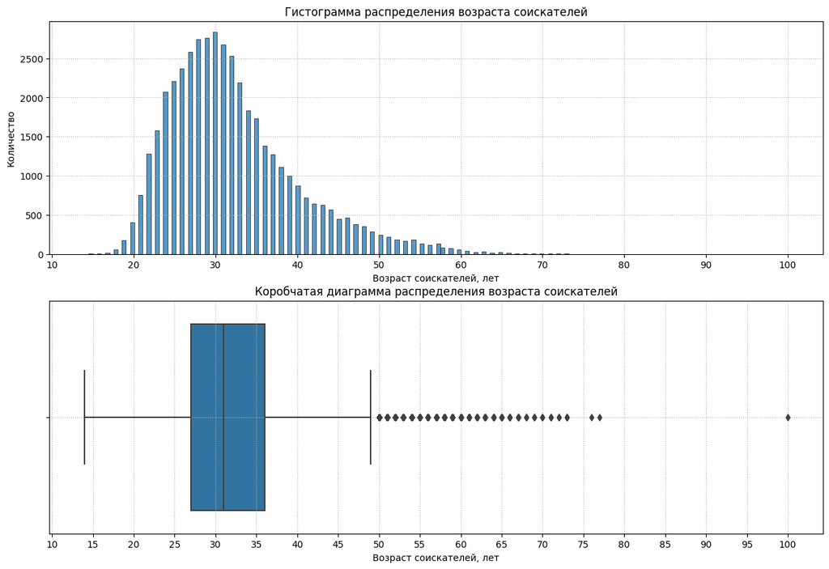

```python
# для настройки шага оси х, чтобы лучше было видно значения
from matplotlib import ticker

fig, axes = plt.subplots(nrows=2, ncols=1, figsize=(15, 10))

# настраиваем гистограмму
histplot = sns.histplot(data=hh_df, x='Возраст', ax=axes[0])
histplot.set_title('Гистограмма распределения возраста соискателей')
histplot.set_xlabel('Возраст соискателей, лет')
histplot.set_ylabel('Количество')
histplot.xaxis.set_major_locator(ticker.MultipleLocator(10)) # меняем шаг оси х на 10 лет
histplot.grid(linestyle=':')

# настраиваем коробчатую диаграмму
boxplot = sns.boxplot(data=hh_df, x='Возраст', ax=axes[1])
boxplot.set_title('Коробчатая диаграмма распределения возраста соискателей')
boxplot.set_xlabel('Возраст соискателей, лет')
boxplot.xaxis.set_major_locator(ticker.MultipleLocator(5)) # меняем шаг оси х на 5 лет
boxplot.grid(linestyle=':');

#display(hh_df[hh_df['Возраст'] < 15])
```

**Вывод.** Получили положительно скошенное распределение. Из распределения признака *'Возраст'* видно, что большинству соискателей 30 лет. Диапазон возрастов соискателей от 14 до 100 лет, при этом основная масса соискателей находятся в диапазоне от 14 до 49 лет, а половина соискателей не моложе 31 года. В данных присутствует аномалия - это соискатель в возрасте 100 лет. Также выбросом является соискатель в возрасте 14 лет, если обратиться к строке данного соискателя, то видно, что его опыт работы 477 месяцев (больше 39 лет), что в принципе невозможно. Эти данные в значительной степени искажают распределение, поэтому рекомендуется их исключить из рассматриваемой таблицы.

2. Постройте распределение признака **"Опыт работы (месяц)"**. Опишите данное распределение, отвечая на следующие вопросы: чему равна мода распределения, каковы предельные значения признака, в каком примерном интервале находится опыт работы большинства соискателей? Есть ли аномалии для признака опыта работы, какие значения вы бы причислили к их числу?

*Совет: постройте гистограмму и коробчатую диаграмму рядом.*

```
1188.0
```

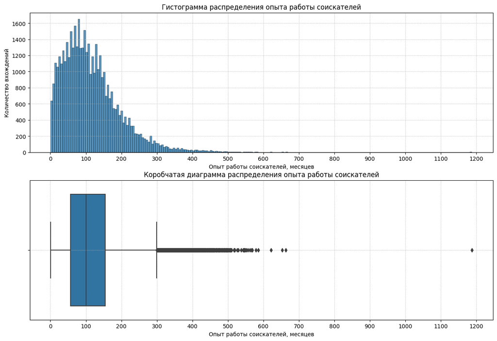

```python
# для настройки шага оси х, чтобы лучше было видно значения
from matplotlib import ticker

fig, axes = plt.subplots(nrows=2, ncols=1, figsize=(15, 10))

# настраиваем гистограмму
histplot = sns.histplot(data=hh_df, x='Опыт работы (месяц)', ax=axes[0])
histplot.set_title('Гистограмма распределения опыта работы соискателей')
histplot.set_xlabel('Опыт работы соискателей, месяцев')
histplot.set_ylabel('Количество вхождений')
histplot.xaxis.set_major_locator(ticker.MultipleLocator(100)) # меняем шаг оси х на 10 лет
histplot.grid(linestyle=':')

# настраиваем коробчатую диаграмму
boxplot = sns.boxplot(data=hh_df, x='Опыт работы (месяц)', ax=axes[1])
boxplot.set_title('Коробчатая диаграмма распределения опыта работы соискателей')
boxplot.set_xlabel('Опыт работы соискателей, месяцев')
boxplot.xaxis.set_major_locator(ticker.MultipleLocator(100)) # меняем шаг оси х на 5 лет
boxplot.grid(linestyle=':');

print(hh_df['Опыт работы (месяц)'].max())
```

3. Постройте распределение признака **"ЗП (руб)"**. Опишите данное распределение, отвечая на следующие вопросы: каковы предельные значения признака, в каком примерном интервале находится заработная плата большинства соискателей? Есть ли аномалии для признака возраста? Обратите внимание на гигантские размеры желаемой заработной платы.

*Совет: постройте гистограмму и коробчатую диаграмму рядом.*

```python
histplot = px.histogram(
    data_frame=hh_df,
    x='ЗП (руб)',
    height=500,
    width=1000,
    marginal='box'
    )
histplot.update_layout(
    title='Гистограмма и коробчатая диаграмма распределения желаемой заработной платы соискателей',
    xaxis_title='Желаемая заработная плата, руб.',
    yaxis_title='Количество'
)
histplot.show()

#display(hh_df[hh_df['ЗП (руб)'] < 100])
```

**Вывод.** Признак *'ЗП (руб)'* имеет положительно скошенное распределение (можно было бы отнести распределение к гребенчатому, но мы знаем, что данные вводятся соискателем вручную, а люди склонны округлять желаемую сумму до целого, поэтому гистограмма имеет гребенчатый вид, но все же распределение положительно скошенное). Большинство соискателей расчитывают на заработную плату от 42.5 до 57.5 тысяч руб., при этом 50% соискателей желают зарплату 59 тысяч руб. А весь диапазон желаемой заработной платы от 1 до 24304876 руб (примерно 24 млн. руб.). В данных присутствуют аномальные значения зарплат:

- 128 указали размер желаемой заработной платы меньше 2500 руб., из них 43 соискателя указали заработную плату до 100 руб., что может быть потенциальным выбросом.
- 5 соискателей указали желаемую заработную плату более 1 миллиона руб., что тоже может быть выбросом и в значительной стемени искажать графики.
4. Постройте диаграмму, которая показывает зависимость **медианной** желаемой заработной платы (**"ЗП (руб)"**) от уровня образования (**"Образование"**). Используйте для диаграммы данные о резюме, где желаемая заработная плата меньше 1 млн рублей.

*Сделайте выводы по представленной диаграмме: для каких уровней образования наблюдаются наибольшие и наименьшие уровни желаемой заработной платы? Как вы считаете, важен ли признак уровня образования при прогнозировании заработной платы?*

```python
#сформируем с помощью группировки таблицу с необходимыми данными
bar_plot_data = hh_df[hh_df['ЗП (руб)'] < 1000000].groupby('Образование', as_index=False).median(numeric_only=True)

barplot = px.bar(
    data_frame=bar_plot_data,
    x='Образование',
    y='ЗП (руб)',
    title='Медианная заработная плата в зависимости от уровня образования'
)

barplot.show();
```

**Вывод.** Наибольший уровень заработной платы ожидают соискатели с высшим образованием, а наименьший - с средним и средним специальным. Разница между средней желаемой заработной платой у соискателей с высшим и неоконченным высшим составляет 10 тысяч руб. (20%), как и между неоконченным высшим и средним или средним специальным уровнями образования. Разный уровень заработной платы можно объяснить количеством затраченного времени и ресурсов при получении образования, а также сложности, которая присуща разным уровням образования. Поскольку разница между уровнями значительная, то при прогнозировании ожидаемой заработной платы определенно имеет значение уровень образования соискателя.

5. Постройте диаграмму, которая показывает распределение желаемой заработной платы (**"ЗП (руб)"**) в зависимости от города (**"Город"**). Используйте для диаграммы данные о резюме, где желая заработная плата меньше 1 млн рублей.

*Сделайте выводы по полученной диаграмме: как соотносятся медианные уровни желаемой заработной платы и их размах в городах? Как вы считаете, важен ли признак города при прогнозировании заработной платы?*

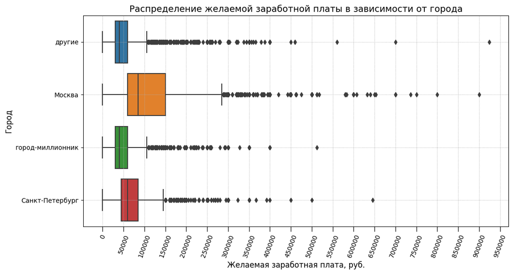

```python
#сформируем с помощью группировки таблицу с необходимыми для графика данными
box_plot_data = hh_df[hh_df['ЗП (руб)'] < 1000000]

fig = plt.figure(figsize=(12, 6))
boxplot = sns.boxplot(
    data=box_plot_data,
    x='ЗП (руб)',
    y='Город'
)
boxplot.set_title('Распределение желаемой заработной платы в зависимости от города', fontsize=14)
boxplot.set_xlabel('Желаемая заработная плата, руб.', fontsize=12)
boxplot.set_ylabel('Город', fontsize=12)
boxplot.tick_params(axis='x',rotation=70, size=8)
boxplot.xaxis.set_major_locator(ticker.MultipleLocator(50000))
boxplot.grid(linestyle=':');
```

**Вывод.** Наибольший медианный уровень желаемой заработной платы равен 80 тысячам руб., его указывают соискатели из города Москва, на втором месте Санкт-Петербург - 60 тысяч руб. А вот в городах-миллионниках и других равны и медиана (40 тысяч руб.) и размах (от 0 до 105 тысяч руб.). Самый большой разброс величины заработных плат у соискателей из Москвы - от 0 до 280 тысяч руб. Так как медианные значения желаемой заработной платы в городах отличаются в значительной степени (для соискателя из города-миллионника медианная зарплата в 2 раза меньше, чем для соискателя из Москвы), то признак *'Город'* имеет большое влияние при определении ожидаемой заработной платы.

6. Постройте **многоуровневую столбчатую диаграмму**, которая показывает зависимость медианной заработной платы (**"ЗП (руб)"**) от признаков **"Готовность к переезду"** и **"Готовность к командировкам"**. Проанализируйте график, сравнив уровень заработной платы в категориях.

```python
#сформируем с помощью группировки таблицу с необходимыми данными
multybar_plot_data = hh_df[hh_df['ЗП (руб)'] < 1000000].groupby(
    ['Готовность к переезду', 'Готовность к командировкам'],
    as_index=False
)['ЗП (руб)'].median()

barplot = px.bar(
    data_frame=multybar_plot_data,
    x='ЗП (руб)',
    y='Готовность к переезду',
    color='Готовность к командировкам',
    barmode='group',
    width=1000,
    labels={'ЗП (руб)': 'Желаемая заработная плата, тыс.руб.'},
    title='Зависимость медианной заработной платы от готовности к переездам и/или командировкам'
)
barplot.show()

print(hh_df[(hh_df['Готовность к переезду'] == True)&(hh_df['Готовность к командировкам'] == True)&(hh_df['ЗП (руб)'] < 1000000)]['ЗП (руб)'].median())
```

```
65535.0
```

**Вывод.** Наибольший медианный уровень желаемой заработной платы равен 65,5 тысячам руб., и характерен для соискателей готовых и к командировкам и к переезду, на втором месте соискатели готовые к командировкам, но не готовые менять место жительства с мединной заработной платой 60 тысяч руб. Из диаграммы можно заметить, что готовность к командировкам в большей степени влияет на ожидаемую заработную плату, чем готовность к переезду. Это объясняется тем, что чаще командировки являются спецификой работы менеджеров и руководителей, а также людей работающих в иностранных компаниях, что влечет за собой и более высокие требования заработной платы. В любом случе признаки *'Готовность к переезду'* и *'Готовность к командировкам'* нужно учитывать при определении ожидаемой заработной платы.

7. Постройте сводную таблицу, иллюстрирующую зависимость **медианной** желаемой заработной платы от возраста (**"Возраст"**) и образования (**"Образование"**). На полученной сводной таблице постройте **тепловую карту**. Проанализируйте тепловую карту, сравнив показатели внутри групп.

```python
# Создаем сводную таблицу для графика
pivot_data = hh_df.pivot_table(
    values='ЗП (руб)',
    index='Образование',
    columns='Возраст',
    aggfunc='median',
    fill_value=0
)

# Рисуем тепловую карту
heatmap = px.imshow(
    pivot_data,
    color_continuous_scale='YlOrRd',
    aspect='auto',
    title='Тепловая карта  зависимости медианной желаемой заработной платы от возраста и уровня образования',
    labels=dict(x='Возраст соискателей, лет', y='Уровень образования', color='Размер желаемой заработной платы, руб.')
)

heatmap.show()
```

**Вывод.** Из графика видно, что соискатели младше 17 и старше 50 лет чаще не указывают размер желаемой заработной платы или указывают ее равной 0. Также можно заметить трех соискателей 17 лет и младше, которые указали наличие высшего образования и их ожидания заработной платы выше 60 тысяч руб. - эти данный можно отнести к выбросам, так как в норме наличие высшего образования возможно только для гениев, закончивших школу и университет экстерном, и такие данные лучше исключить из выборки, так как они в значительной мере искажают график, а процент таких данных ничтожно мал. Так же можно заметить, что с возрастом для соискателей имеющих высшее образование растет и размер ожидаемой медианной заработной платы, для среднего и среднего специально он растет в меньшей степени и более плавно, это обусловлено карьерным ростом и увеличением опыта работы. Вызывают сомнение соискатели с высшим образованием младше 20 лет, возможно эти соискатели намерено исказили свои данные указав вместо неоконченного высшего - высшее образование. Также виден возрастной выброс, это соискатель в возрасте 100 лет с желаемой медианной заработной платой 60 тыс.руб. Кроме того исходя из интенсивности повышения ожидаемой медианной заработной платы можно заключить, что для соискателей с высшим образованием карьерный рост самый быстрый в сравнении с остальными уровнями образования.

8. Постройте **диаграмму рассеяния**, показывающую зависимость опыта работы (**"Опыт работы (месяц)"**) от возраста (**"Возраст"**). Опыт работы переведите из месяцев в года, чтобы признаки были в едином масштабе. Постройте на графике дополнительно прямую, проходящую через точки (0, 0) и (100, 100). Данная прямая соответствует значениям, когда опыт работы равен возрасту человека. Точки, лежащие на этой прямой и выше нее - аномалии в наших данных (опыт работы больше либо равен возрасту соискателя)

```
Количество точек, лежащих строго выше построенной прямой: 7
```

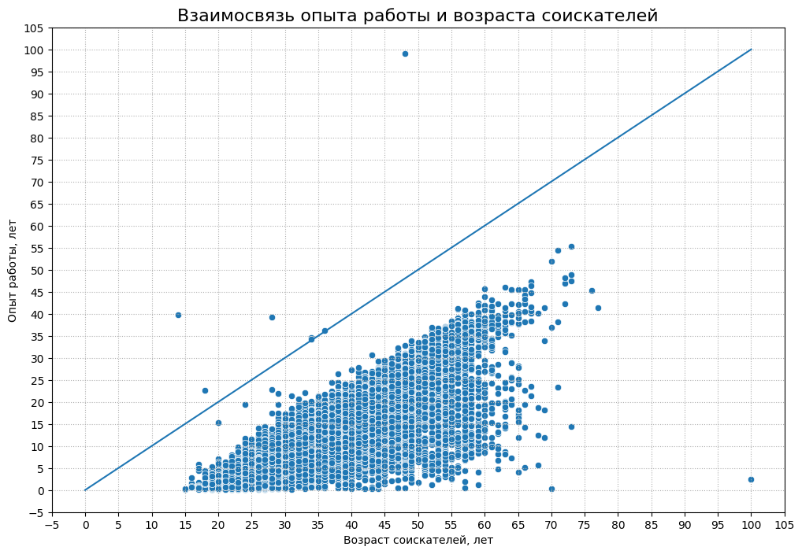

```python
scatterplot_data = hh_df.copy()
scatterplot_data['Опыт работы (лет)'] = scatterplot_data['Опыт работы (месяц)']/12

fig = plt.figure(figsize=(12, 8))

scatterplot = sns.scatterplot(
    data=scatterplot_data,
    x='Возраст',
    y='Опыт работы (лет)'
)
sns.lineplot(x=[0, 100], y=[0, 100])
scatterplot.set_title('Взаимосвязь опыта работы и возраста соискателей', fontsize=16)
scatterplot.set_xlabel('Возраст соискателей, лет')
scatterplot.set_ylabel('Опыт работы, лет')
scatterplot.xaxis.set_major_locator(ticker.MultipleLocator(5))
scatterplot.yaxis.set_major_locator(ticker.MultipleLocator(5))
scatterplot.grid(linestyle=':');
anomal_data = scatterplot_data[scatterplot_data['Опыт работы (лет)'] > scatterplot_data['Возраст']].shape[0]
print('Количество точек, лежащих строго выше построенной прямой:', anomal_data)
```

**Вывод.** Из диаграммы видно, что мы имеем дело с линейной положительной коореляцией, где с возрастом растет и опыт работы. Но можно также заметить несколько точек, где опыт работы превышает возраст или они практически равны, что в реальной жизни невозможно, например соискатель в возрасте 20 лет не может иметь опыт работы равный 15 лет. Эти данные являются ошибочными и их можно отнести к выбросам.

**Дополнительные баллы**

Для получения 2 дополнительных баллов по разведывательному анализу постройте еще два любых содержательных графика или диаграммы, которые помогут проиллюстрировать влияние признаков/взаимосвязь между признаками/распределения признаков. Приведите выводы по ним. Желательно, чтобы в анализе участвовали признаки, которые мы создавали ранее в разделе "Преобразование данных".

```python
# Создаем сводную таблицу для графика
pivot_data = hh_df.pivot_table(
    values='ЗП (руб)',
    index='Образование',
    columns='Город',
    aggfunc='median',
    fill_value=0
)
# Рисуем тепловую карту
heatmap = px.imshow(
    pivot_data,
    color_continuous_scale='YlOrRd',
    aspect='auto',
    title='Тепловая карта медианной желаемой заработной платы в разрезе уровня образования и города',
    labels=dict(x='Город', y='Уровень образования', color='Размер желаемой заработной платы, руб.')
)

heatmap.show()
```

**Вывод.** Как можно заметить по тепловой карте самый высокий уровень ожидаемой медианной заработной платы у соискателей с высшим образованием из Москвы, на втором месте соискатели из Санкт-Петербурга, это обусловлено тем, что уровень образования и стоимость образования и жизни в этих городах выше, чем в других. При этом наименее требовательные к размеру зарплаты специалисты со средним специальным образованием в городах-миллионниках и других. Поэтому для работодателей из Москвы и Санкт-Петербурга выгоднее искать соискателей из городов-миллионников и других городов готовых к переезду.

```python
#сформируем с помощью группировки таблицу с необходимыми данными
multybar_plot_data = hh_df[hh_df['ЗП (руб)'] < 1000000].groupby(['полный день', 'полная занятость'], as_index=False)['ЗП (руб)'].median()

barplot = px.bar(
    data_frame=multybar_plot_data,
    x='ЗП (руб)',
    y='полный день',
    color='полная занятость',
    barmode='group',
    width=1000,
    labels={'ЗП (руб)': 'Желаемая заработная плата, руб.', 'полный день':'Полный день', 'полная занятость':'Полная занятость'},
    title='Зависимость медианной заработной платы от работы полный день с полной занятостью'
)
barplot.show()
```

**Вывод.** Из графика видно, что соискатели готовые работать полный день с полной занятостью желают примерно на 30% выше медианную заработную плату, чем соскатели не готовые к полной занятости. Аналогичная ситуация когда соискатель не готов работать полный день, но согласен на полную занятость. А вот медианная заработная плата не готовых на полный день и полную занятость соискателей отличается в 2 раза от согласных на то и на другое. Что объясняется тем, что соискатели ищут не основную работу, а подработку, либо совмещают учебу с работой, поэтому и требование к заработной плате у них не такие высокие.

# Очистка данных

1. Начнем с дубликатов в наших данных. Найдите **полные дубликаты** в таблице с резюме и удалите их.

```python
duplicates = hh_df[hh_df.duplicated(subset=hh_df.columns)]
hh_df = hh_df.drop_duplicates()
print('Количество полных копий:', duplicates.shape[0])
```

```
Количество полных копий: 161
```

2. Займемся пропусками. Выведите информацию **о числе пропусков** в столбцах.

```python
null_values = hh_df.isnull().sum()
display(null_values[null_values > 0])
```

```
Последнее/нынешнее место работы      1
Последняя/нынешняя должность         2
Опыт работы (месяц)                168
dtype: int64
```

3. Итак, у нас есть пропуски в 3ех столбцах: **"Опыт работы (месяц)"**, **"Последнее/нынешнее место работы"**, **"Последняя/нынешняя должность"**. Поступим следующим образом: удалите строки, где есть пропуск в столбцах с местом работы и должностью. Пропуски в столбце с опытом работы заполните **медианным** значением.

```python
hh_df = hh_df.dropna(subset=['Последнее/нынешнее место работы', 'Последняя/нынешняя должность'])
hh_df['Опыт работы (месяц)'] = hh_df['Опыт работы (месяц)'].fillna(hh_df['Опыт работы (месяц)'].median())
print('Среднее значение признака "Опыт работы (месяц)":', round(hh_df['Опыт работы (месяц)'].mean()))
```

```
Среднее значение признака "Опыт работы (месяц)": 114
```

4. Мы добрались до ликвидации выбросов. Сначала очистим данные вручную. Удалите резюме, в которых указана заработная плата либо выше 1 млн. рублей, либо ниже 1 тыс. рублей.

```python
anomalies_salary = hh_df[(hh_df['ЗП (руб)'] > 1000000) | (hh_df['ЗП (руб)'] < 1000)]
hh_df = hh_df.drop(anomalies_salary.index)
print('Найдено выбросов:', anomalies_salary.shape[0])
```

```
Найдено выбросов: 89
```

5. В процессе разведывательного анализа мы обнаружили резюме, в которых **опыт работы в годах превышал возраст соискателя**. Найдите такие резюме и удалите их из данных

```python
#здесь я бы еще удалила те, в которых разница между возрастом и опытом работы составляет менее 12 лет, так как это невозможно
#anomalies_age = hh_df[(hh_df['Возраст'] - hh_df['Опыт работы (месяц)']/12) < 12]
#print('Найдено выбросов:', anomalies_age.shape[0])
anomalies_age = hh_df[hh_df['Опыт работы (месяц)']/12 > hh_df['Возраст']]
hh_df = hh_df.drop(anomalies_age.index)
print('Найдено выбросов:', anomalies_age.shape[0])
```

```
Найдено выбросов: 7
```

6. В результате анализа мы обнаружили потенциальные выбросы в признаке **"Возраст"**. Это оказались резюме людей чересчур преклонного возраста для поиска работы. Попробуйте построить распределение признака в **логарифмическом масштабе**. Добавьте к графику линии, отображающие **среднее и границы интервала метода трех сигм**. Напомним, сделать это можно с помощью метода axvline. Например, для построение линии среднего будет иметь вид:

`histplot.axvline(log_age.mean(), color='k', lw=2)`

В какую сторону асимметрично логарифмическое распределение? Напишите об этом в комментарии к графику. Найдите выбросы с помощью метода z-отклонения и удалите их из данных, используйте логарифмический масштаб. Давайте сделаем послабление на **1 сигму** (возьмите 4 сигмы) в **правую сторону**.

Выведите таблицу с полученными выбросами и оцените, с каким возрастом соискатели попадают под категорию выбросов?

```
0.4708094957161126
```

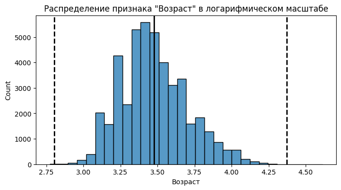

```python
fig, ax = plt.subplots(1, 1, figsize=(8, 4))
log_age = np.log(hh_df['Возраст'] + 1)
histplot = sns.histplot(log_age, bins=30, ax=ax)
histplot.axvline(log_age.mean(), color='k', lw=2)
histplot.axvline(log_age.mean()+ 4 * log_age.std(), color='k', ls='--', lw=2)
histplot.axvline(log_age.mean()- 3 * log_age.std(), color='k', ls='--', lw=2)
histplot.set_title('Распределение признака "Возраст" в логарифмическом масштабе');

print(log_age.skew());
```

```python
import numpy as np
import pandas as pd

def outliers_z_score_mod(data, feature, log_scale=False, left=3, right=3):
    if log_scale:
        x = np.log(data[feature]+1)
    else:
        x = data[feature]
    mu = x.mean()
    sigma = x.std()
    lower_bound = mu - left * sigma
    upper_bound = mu + right * sigma
    outliers = data[(x < lower_bound) | (x > upper_bound)]
    cleaned = data[(x > lower_bound) & (x < upper_bound)]
    return outliers, cleaned

outliers, cleaned = outliers_z_score_mod(hh_df, 'Возраст', left=3, right=4, log_scale=True)
print(f'Number of outliers by z-score: {outliers.shape[0]}')
print(f'Resulting Number of Records: {cleaned.shape[0]}')
```

```
Number of outliers by z-score: 3
Resulting Number of Records: 44482
```

```python
display(hh_df.info())
hh_df.to_csv('data/dst-3.0_16_1_hh_database_cleaned.csv')
```

```
<class 'pandas.core.frame.DataFrame'>
Int64Index: 44485 entries, 0 to 44743
Data columns (total 23 columns):
 #   Column                           Non-Null Count  Dtype
---  ------                           --------------  -----
 0   Ищет работу на должность:        44485 non-null  object
 1   Последнее/нынешнее место работы  44485 non-null  object
 2   Последняя/нынешняя должность     44485 non-null  object
 3   Обновление резюме                44485 non-null  object
 4   Авто                             44485 non-null  object
 5   Образование                      44485 non-null  object
 6   Пол                              44485 non-null  object
 7   Возраст                          44485 non-null  int64
 8   Опыт работы (месяц)              44485 non-null  float64
 9   Город                            44485 non-null  object
 10  Готовность к переезду            44485 non-null  bool
 11  Готовность к командировкам       44485 non-null  bool
 12  полная занятость                 44485 non-null  bool
 13  частичная занятость              44485 non-null  bool
 14  стажировка                       44485 non-null  bool
 15  проектная работа                 44485 non-null  bool
 16  волонтерство                     44485 non-null  bool
 17  полный день                      44485 non-null  bool
 18  гибкий график                    44485 non-null  bool
 19  удаленная работа                 44485 non-null  bool
 20  сменный график                   44485 non-null  bool
 21  вахтовый метод                   44485 non-null  bool
 22  ЗП (руб)                         44485 non-null  float64
dtypes: bool(12), float64(2), int64(1), object(8)
memory usage: 4.6+ MB
```

```
None
```

**Вывод.** Благодаря преобразованиям и очистке удалось избавится от пустых значений, количество записей сократилось на 259 (за счет удаления выбросов и пустых значений) и теперь составляет 44485. Количество столбцов увеличилось практически в два раза за счет признаков-мигалок, но количество признаков с типом данных object сократилось с 12 до 8, при этом значимые признаки были преобразованы в форматы данных удобные для модели (числовой и булевый).